# **Anatomy Of A Modern Hit**

### *What Makes a Great Song?*

Written by Jaya Dhariwal and Zach Barsamian

## Project Website

[Click here!](https://jayadhariwal.github.io/musicanalysis.github.io/)

## Project Goal

In this project, we aim to determine what metrics can be best used to predict the success of a song. Are the most popular songs topping the charts every week? Getting the most music video views on Youtube?

For this milestone, our aim is to specifically see the correlation between different features of each song. We look at the top 200 weekly songs on Spotify, specifically at the average popularity of a song and how long that popularity persists. Then, we look at the music video views of a different set of songs on Youtube. This provides a different angle to measure online popularity that we can compare to chart performance. Finally, we look at Grammy nomination data. We take a Grammy nomination to be one of the highest tangible success metrics a song can achieve and explore potential relationships between a song’s online popularity and its critical reception.

Is music now an entirely digital medium? Are there other significant factors at play that will impede our predictive capability? Find out below.

## Collaboration Plan

We will plan to meet 10-12 every Tuesday at the Hub to discuss the project. We will agree on each of our assignments for that following week and review what we have completed in the previous week. Our collaboration will be a mix of asynchronous work and in person collaboration, with additional meetings scheduled as needed. We have created a shared Google Drive folder and Google Colab page where we will work together.

## Data Set 1

### Describing the set

We obtained our first dataset from a web scrape of Spotify's Charts website. We scraped 418 weeks worth of data for the top 200 songs by streams on Spotify, every week, starting with the last full week of 2016 and going to the last full week of 2024. The scraper is [linked here](https://raw.githubusercontent.com/jayadhariwal/musicanalysis.github.io/refs/heads/main/spot_scrape.py), but the basic methodology was to use Selenium's Chrome webdriver to open an automated Chrome browser and navigate to the Spotify Charts top 200 weekly page. Starting at the earliest available table, we parse the 200 table rows on that week's page, and then navigate to the next week and repeat that process 418 times.

After loading and tidying the DataFrame, we are able to analyze the data. Using The Weeknd's Starboy as an example, we see how the scraped streaming data matches up to the actual streaming numbers shown on the Spotify website. Then, we use a cluster model to analyze archetypes within the chart data on Spotify. Later, we see how these archetypes match up to other metrics like Youtube views and Grammy nominations.

### Loading and Tidying

**Cells are commented with specific data operation explanations where necessary**

First, we will download the correct libraries to analyze the data.

```python
import pandas as pd
import numpy as np
import matplotlib.pyplot as plt
import seaborn as sns
from datetime import date, timedelta
from sklearn.cluster import KMeans
from sklearn.preprocessing import StandardScaler
```

Then we will mount the google drive.

```python
from google.colab import drive
drive.mount('/content/drive')
```

Now we need to load the first two DataFrames. The scraper bugged out on our first attempt at week 277, and so we had to run it again for the other half of the data, resulting in two DataFrames we had to join together. Below we load them both and tidy them a bit before joining them together.

```python
streams_pt1 = pd.read_csv('/content/drive/MyDrive/Project Datasets/spotify_weekly_charts_2016-2025.csv')
streams_pt2 = pd.read_csv('/content/drive/MyDrive/Project Datasets/spotify_weekly_charts_2022-2025.csv')
```

The week indexing didn't work properly, so we ended up with an awkwardly formatted date column. However, it is easy to strip these values down to an integer for each week. Then, we concatenate Part 1 and Part 2 so that they combine sequentially, and we reset the index to see how many observations we have.

```python
#replacing date index column of pt1 with numbered indices
streams_pt1["date_week"] = streams_pt1["date_week"].astype(str).str.strip("week_index_").replace("12/29/2016", "0").astype(int)

#replacing date index column of pt2 with numbered indices,
#incrementing by 277 because pt1 ends on 276
streams_pt2["date_week"] = streams_pt2["date_week"].astype(str).str.strip("week_index_").replace("04/21/2022", "0").astype(int) + 277
```

```python
all_streams = pd.concat([streams_pt1, streams_pt2])
```

```python
all_streams = all_streams.reset_index(drop=True)
```

With our DataFrames combined, let's add a better date column to make the timeframe more interpretable. From Python's Datetime, we have a handy date calculator that can take in our week indices and output the actual date. We can create an associative table mapping week index to actual date, and then left join it with our streaming data.

```python
dates = pd.Series() #series to hold (week index, actual date) pairs

curr = date(2016, 12, 29) #starts on our first week

#loops 418 times for all of our scraped weeks
for i in range(418):
  dates[i] = curr #creates a new pair in dates with (week index, actual date)
  curr = curr + timedelta(days=7) #adds 7 days to curr so the next date increments by a week

#now we have an associative table that we can merge with our streams table.
dates_df = dates.to_frame()
dates_df = dates_df.reset_index()
dates_df.columns = ['date_week', 'actual_date']
```

```python
#Merging streams and dates. This won't be used for calculations, but its nice to have an
# immediate reference of the date of each week.
merged_df = all_streams.merge(dates_df, on="date_week", how='left')
```

Next, we want to add a rank column for a more continuous measurement of week-by-week popularity. The songs are already in order for each week because the Charts page ranked them from 1-200, but we didn't include this column in our scrape, so we have to construct it manually.

```python
merged_df['rank'] = merged_df.groupby('date_week')['weekly_streams'].rank(method='min', ascending=False).astype(int)
```

Right after we added the rank column, we realized something was wrong: in the Charts data, occasionally a row is just skipped, and the index increments by two instead of one. This meant that a few weeks were missing a few songs, completely at random. If we had included rank in our scrape, this wouldn't have been an issue for us. However, due to our disastrous lack of foresight, manually reconstructing the rank column meant ignoring the occasional skip that happens in the real data.

In short, we had to locate these skips manually. We looked at all the 200 rank songs in the DataFrame; each week that was missing was a week that had <200 songs, and would not show up in this view. For each of those weeks, we scrolled through the corresponding Charts page to find the skipped rank/s. Then, we added a pair of {song name: week it needs to be incremented} to the dictionary below, and moved on to the next absent week.

When that was done, we wrote the code below to iterate through the dictionary. It locates each song, increments it and all higher ranked songs from the same week by one, and then moves onto the next song. Once finished, every week has a 200th ranked song, and the ranks in our data now perfectly match the ranks from the site.

```python
#Mapping song title to the index of the week where it needs to be incremented
target_dict = {
    "I'm the One (feat. Justin Bieber, Quavo, Chance the Rapper & Lil Wayne)": 29,
    "Know No Better": 29,
    "Redbone": 29,
    "Strip That Down (feat. Quavo)": 29,
    "What About Us": 45,
    "Leave Before You Love Me (with Jonas Brothers)": 240,
    "Don't Go Yet": 241,
    "ACORDA PEDRINHO": 284,
    "Perfect": 285,
    "I Love You So": 314,
    "CAIRO": 315,
    "Shinunoga E-Wa": 316,
    "VIBE (feat. Jimin of BTS)": 317,
    "Until I Found You": 318,
    "Dandelions": 319,
    "Late Night Talking": 320,
    "PLAYA DEL INGLÉS": 321,
    "Moscow Mule": 321,
    "Without Me": 322,
    "Love On The Brain": 322,
    "Yellow": 323,
    "Malas Decisiones": 323,
    "Sem Aliança no Dedo": 324
}

for title, week in target_dict.items():
  target_rank_series = merged_df.loc[
      (merged_df['date_week'] == week) & (merged_df['title'] == title),
      'rank'
  ]
  target_rank = target_rank_series.iloc[0]

  rows_to_fix = (merged_df['date_week'] == week) & (merged_df['rank'] >= target_rank)

  merged_df.loc[rows_to_fix, 'rank'] = merged_df.loc[rows_to_fix, 'rank'] + 1
```

```python
print(np.array_equal(merged_df[merged_df["rank"] == 200]["date_week"].values, np.arange(418)))
```

```
True
```

Finally, we're ready to look at our Dataframe of 8 full years worth of weekly chart data.

```python
merged_df.head()
```

|  | date_week | title | artist | weekly_streams | actual_date | rank |
| --- | --- | --- | --- | --- | --- | --- |
| 0 | 0 | Starboy | The Weeknd, Daft Punk | 25286465 | 2016-12-29 | 1 |
| 1 | 0 | Closer | The Chainsmokers, Halsey | 22047697 | 2016-12-29 | 2 |
| 2 | 0 | Rockabye (feat. Sean Paul & Anne-Marie) | Clean Bandit, Anne-Marie, Sean Paul | 19794482 | 2016-12-29 | 3 |
| 3 | 0 | Let Me Love You | DJ Snake, Justin Bieber | 17965723 | 2016-12-29 | 4 |
| 4 | 0 | Don't Wanna Know (feat. Kendrick Lamar) | Maroon 5, Kendrick Lamar | 16966668 | 2016-12-29 | 5 |

```python
merged_df.tail()
```

|  | date_week | title | artist | weekly_streams | actual_date | rank |
| --- | --- | --- | --- | --- | --- | --- |
| 83572 | 417 | Something Just Like This | The Chainsmokers, Coldplay | 9576032 | 2024-12-26 | 196 |
| 83573 | 417 | Don't Stop Believin' (2022 Remaster) | Journey | 9545988 | 2024-12-26 | 197 |
| 83574 | 417 | Flowers | Miley Cyrus | 9523995 | 2024-12-26 | 198 |
| 83575 | 417 | on one tonight | Gunna | 9523649 | 2024-12-26 | 199 |
| 83576 | 417 | Perfect | Ed Sheeran | 9495976 | 2024-12-26 | 200 |

```python
merged_df[merged_df['title']== "Starboy"]["weekly_streams"].sum()
```

```
np.int64(2463208139)
```

```python
merged_df[merged_df["title"] == "Starboy"]["title"].count()
```

```
np.int64(221)
```

Now we want to consider what conclusions we can draw from this set. We can't use the streaming figures for cumulative measurement, as seen by the Starboy example. However, we look at how popular a song is relative to other songs, and how that metric varies over time. To do this, we need to create two new metrics. The mean rank of a song will represent it's relative popularity for the time it was on the charts. The longevity will measure the number of weeks it charted.

We predict that, based on these features, songs will fall into distinct categories that can roughly be considered their "overall popularity". Specifically, we think that at least three distinct categories will emerge: massive hits, average hits, and "tiktok songs". For example, some songs that spend a while on the chart might peak with a really low (good) rank, but then rise to the mid-100s for the main duration of their stay. These "tiktok" songs would have high longevity and high mean rank, meaning that although they charted for a while, they can't be considered as popular as songs with similar longevity and a consistently lower rank--average or massive hits.

To test this hypothesis, we ran an unsupervised k-means cluster model. Four random original centroids are created within the dataset, and all other data points are assinged a cluster based on the closest centroid by euclidian distance. The centroids are then updated to the mean of each cluster, and the assignment process is repeated. This goes on until the centroids stop moving, at which point four clusters have been found based on similarity.

```python
#for each artist, a) how much time did they spend on the charts, and
#b) what was their mean rank throughout this time
song_features_df = merged_df.groupby(['title', 'artist']).agg(
    longevity=('date_week', 'nunique'),
    mean_rank=('rank', 'mean')
).reset_index()

#features dataframe to train cluster model
features_df = song_features_df[['longevity', 'mean_rank']]

#initialize the scaler and normalize features
scaler = StandardScaler()
features_scaled = scaler.fit_transform(features_df)

#running kmeans model with 4 original centroids, choosing the same
# random points every time.
kmeans = KMeans(n_clusters=4, random_state=42, n_init='auto')

# Add the cluster labels back to the original DataFrame
song_features_df['cluster'] = kmeans.fit_predict(features_scaled)

#reverse-scales the final centroids to make their values interpretable
original_centroids = scaler.inverse_transform(kmeans.cluster_centers_)

#dictionary to mapping cluster numbers to more descriptive archetype names
label_map = {
    0: "Album Cuts",
    1: "Brief Hits",
    2: "Popular Hits",
    3: "Massive Hits"
}

#mapping more descriptive archetype names to cluster labels
song_features_df['archetype'] = song_features_df['cluster'].map(label_map)
```

As you can see, our hypothesis was somewhat supported. There is a standout category of massive hits with extremely long longevity and an average mean rank. The next cluster of popular hits has about a third the longevity, but a slightly lower mean rank. Then, instead of there being a category with high longevity and high mean rank--the "tiktok song" category that we predicted--the other two categories are just songs that spent relatively little time on the charts, separated by an average and a low mean rank.

```python
print("Cluster Centroids (Longevity, Mean Rank):")
print(original_centroids)
```

```
Cluster Centroids (Longevity, Mean Rank):
[[  4.8477349  159.53180871]
 [  7.15856777  90.53244029]
 [ 47.18013245  83.7742013 ]
 [157.06542056 106.04234181]]
```

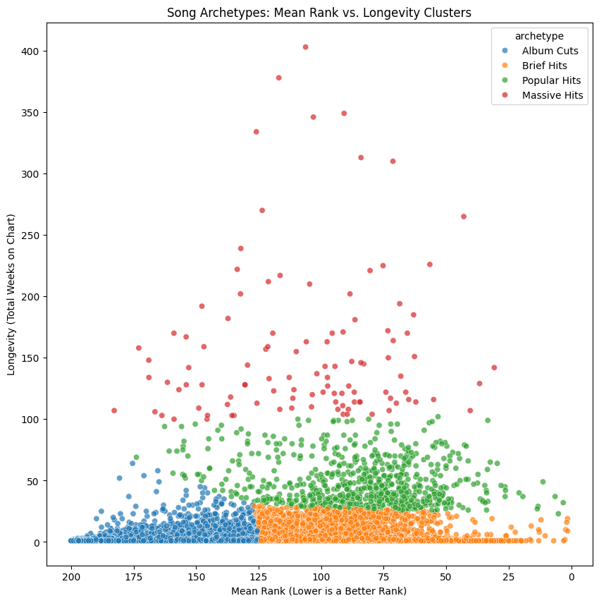

```python
#Viz for cluster model
plt.figure(figsize=(10, 10)) #large figsize for better readability
sns.scatterplot(
    data=song_features_df,
    x='mean_rank',
    y='longevity',
    hue='archetype', #aesthetics for cluster indication, using mapped archetype column
    palette='tab10', #brighter colors
    legend='full',
    alpha=0.7
)

plt.xlabel("Mean Rank (Lower is a Better Rank)") #more descriptive labels
plt.ylabel("Longevity (Total Weeks on Chart)")
plt.title("Song Archetypes: Mean Rank vs. Longevity Clusters")

plt.gca().invert_xaxis() #to put lower rank (higher popularity) songs on the right
```

While the unsupervised cluster model was useful for analysis of the Spotify chart data, it is difficult to generalize and connect it to our Youtube views data or our Grammy data. For our other future models, we are inclined to use longevity and mean rank to direclty train a classification model. However, the cluster model provides a useful analysis of the different archetypes for song popularity that you see in the data from one, significant streaming platform.

## Data Set 2

### Describing the set

We obtained our second data set, [linked here](https://huggingface.co/datasets/akbargherbal/youtube-music-hits/viewer/default/train?sort%5Bcolumn%5D=year&sort%5Bdirection%5D=asc), from huggingface.co. It presents over 24,000 of the most-listened-to music videos from the last decade. The variables measured include song, artist, year, genre and views. This data was obtained from a Youtube webscrape sourced from Wikidata.

For this dataset, our aim was to compare a new online popularity metric, music video views, to an artist’s success. Although it is not holistic, we use music video popularity as a new metric to represent engagement on social platforms. The engagement on Youtube would ideally be similar to chart popularity, however, Youtube video views are not indicative of how popular a song is on the radio. Since watching a music video takes more active engagement, while listening tends to be more passive, we could think of views as a measure of that active popularity. Additionally, these views are cumulative, and weekly chart measurements are not. This means that we now have two interesting perspectives on digital popularity, but they are not perfectly compatible with each other.

### Loading & Tidying

First, we will upload the second data frame and display the first 5 rows.

```python
youtube_df = pd.read_parquet("hf://datasets/akbargherbal/youtube-music-hits/data/train-00000-of-00001.parquet")
youtube_df.head()
```

|  | youtubeId | itemLabel | performerLabel | youtubeViews | year | genreLabel |
| --- | --- | --- | --- | --- | --- | --- |
| 0 | JGwWNGJdvx8 | Shape of You | Ed Sheeran | 5.534218e+09 | 2017.0 | short film, dance-pop, musical film |
| 1 | RgKAFK5djSk | See You Again | Charlie Puth | 5.016966e+09 | 2015.0 | hip hop music, pop rap |
| 2 | OPf0YbXqDm0 | Uptown Funk | Mark Ronson | 4.362269e+09 | 2014.0 | soul, funk, boogie, disco-pop |
| 3 | tYvFa2ARD24 | Uptown Funk | Mark Ronson | 4.362269e+09 | 2014.0 | soul, funk, boogie, disco-pop |
| 4 | k85mRPqvMbE | Axel F | Crazy Frog | 3.694050e+09 | 2005.0 | dance-pop |

Then, as we are only looking at views and post 2016, we narrow our data frame to song, artist, views and year. We also drop all data pre 2016.

```python
youtube_df = youtube_df[['itemLabel','performerLabel', 'youtubeViews', 'year']]

youtube_df = youtube_df.drop_duplicates() #drop duplicate videos
youtube_df = youtube_df[youtube_df['year'] >= 2016] #restrict to post 2016
youtube_df.head()
```

|  | itemLabel | performerLabel | youtubeViews | year |
| --- | --- | --- | --- | --- |
| 0 | Shape of You | Ed Sheeran | 5.534218e+09 | 2017.0 |
| 10 | Dame Tu Cosita | El Chombo | 3.188181e+09 | 2018.0 |
| 17 | Girls Like You | Cardi B | 2.987593e+09 | 2018.0 |
| 19 | Mi Gente | Willy William | 2.885044e+09 | 2017.0 |
| 21 | Perfect | Ed Sheeran | 2.786524e+09 | 2017.0 |

Then, we drop duplicate data (as some data has been put in twice) and create an artist keys data frame to get rid of any duplicate data.

```python
artist_keys = youtube_df['performerLabel'].drop_duplicates().reset_index(drop=True) #create an artist key dataset that ennumerates the artists
#create keys to get rid of duplicate data
artist_keys_df = pd.DataFrame({
    'artist_id': range(1, len(artist_keys) + 1),
    'performerLabel': artist_keys
})
artist_keys_df.head()
```

|  | artist_id | performerLabel |
| --- | --- | --- |
| 0 | 1 | Ed Sheeran |
| 1 | 2 | El Chombo |
| 2 | 3 | Cardi B |
| 3 | 4 | Willy William |
| 4 | 5 | Halsey |

Then, we replace the performer label column with artist id.

```python
#merge the data frames together then drop the artist column to get rid of duplicate data
youtube_df = youtube_df.merge(artist_keys_df, on='performerLabel', how='left')
youtube_df = youtube_df.drop(columns=['performerLabel'])
#rename the columns for clarity
artist_keys_df = artist_keys_df.rename(columns={'performerLabel': 'Artist'})
youtube_df = youtube_df.rename(columns={'itemLabel': 'Song'})
youtube_df.head()
```

|  | Song | youtubeViews | year | artist_id |
| --- | --- | --- | --- | --- |
| 0 | Shape of You | 5.534218e+09 | 2017.0 | 1 |
| 1 | Dame Tu Cosita | 3.188181e+09 | 2018.0 | 2 |
| 2 | Girls Like You | 2.987593e+09 | 2018.0 | 3 |
| 3 | Mi Gente | 2.885044e+09 | 2017.0 | 4 |
| 4 | Perfect | 2.786524e+09 | 2017.0 | 1 |

## Data Frame 3

### Describing the set

Our third data set, [linked here](https://www.kaggle.com/datasets/kfoster150/grammy-award-nominees-and-winners-1958-2024?resource=download) , which we obtained from Kaggle, presents all grammy nominations and winners from 1958-2024. The variables are year, award show, type of award, song, nominee, and win/loss. This data was obtained from a webscrape on the Grammy website and filled in missing data with information from Wikipedia (linked below).

We plan to use this data to compare popularity on digital platforms to performance on stage at the Grammys. This dataset required a lot of cleaning up, as we only wanted to look at song nominations and awards, not artist nor album nominations/awards. We planned for a song's Grammy nominations and wins to be a tangible metric that may depend but does not rely on a song’s popularity. With a more supposedly "holistic" measurement of success, we can see how a song’s digital popularity measures up to its critical reception. We suspect to find that as a song's music video views and chart popularity increases, the likelihood of winning a Grammy award also increases. How critical are these accolades, really?

**Wikipedia citations to fill in missing spots**

[Wikipedia - Grammy Award for Best Classical Instrumental Solo](https://en.wikipedia.org/wiki/Grammy_Award_for_Best_Classical_Instrumental_Solo)

Wikipedia - Grammy Award for Best Classical Performance – Instrumental Soloist or Soloists (with or without orchestra)

[Wikipedia - Grammy Award for Best Classical Solo Vocal Album](https://en.wikipedia.org/wiki/Grammy_Award_for_Best_Classical_Solo_Vocal_Album)

[Wikipedia - Grammy Award for Best Chamber Music/Small Ensemble Performance](https://en.wikipedia.org/wiki/Grammy_Award_for_Best_Chamber_Music/Small_Ensemble_Performance)

[Wikipedia - Grammy Award for Best New Classical Artist](https://en.wikipedia.org/wiki/Grammy_Award_for_Best_New_Classical_Artist)

### Loading & Tidying

First, we will upload the third data frame and display the first 5 rows.

```python
grammy_df = pd.read_csv('/content/drive/MyDrive/Project Datasets/Grammy Award Nominees and Winners 1958-2024.csv')
```

```python
grammy_df.head()
```

|  | Unnamed: 0 | Year | Ceremony | Award ID | Award Type | Award Name | Work | Nominee | Winner |
| --- | --- | --- | --- | --- | --- | --- | --- | --- | --- |
| 0 | 0 | 1958 | 1 | 587 | Work | Best Recording For Children | Childrens' Marching Song (Album) | Cyril Stapleton | False |
| 1 | 1 | 1958 | 1 | 587 | Work | Best Recording For Children | Mommy, Give Me A Drinka Water (Album) | Danny Kaye | False |
| 2 | 2 | 1958 | 1 | 587 | Work | Best Recording For Children | The Witch Doctor | David Seville And The Chipmunks | False |
| 3 | 3 | 1958 | 1 | 587 | Work | Best Recording For Children | Tubby The Tuba | Jose Ferrer | False |
| 4 | 4 | 1958 | 1 | 587 | Work | Best Recording For Children | Fun In Shariland (Album) | Shari Lewis And Lambchop | False |

```python
grammy_df = grammy_df[['Work','Nominee', 'Winner', 'Year']] #only need the nominee and winner column
grammy_df.head()
grammy_df = grammy_df.dropna(subset=['Work']) #drop all the nan values (as they represent artists themselves getting nominated not a song)
grammy_df = grammy_df[~grammy_df['Work'].astype(str).str.strip().str.endswith('(Album)')] #drop all values that end in (album) to get rid of albums
grammy_df['Nominee'] = grammy_df['Nominee'].str.replace(r'[()]', '', regex=True).str.strip() #get rid of parenthesis
grammy_df['Nominee'] = grammy_df['Nominee'].str.split(',').str[0].str.strip() #get rid of commas
grammy_df = grammy_df.rename(columns={'Work': 'Song'}) #rename for clarity

grammy_df = grammy_df[grammy_df['Year'] >= 2016]
grammy_df.head()
```

|  | Song | Nominee | Winner | Year |
| --- | --- | --- | --- | --- |
| 21258 | 22, A Million | Bon Iver | False | 2016 |
| 21259 | Post Pop Depression | Iggy Pop | False | 2016 |
| 21260 | The Hope Six Demolition Project | PJ Harvey | False | 2016 |
| 21261 | A Moon Shaped Pool | Radiohead | False | 2016 |
| 21262 | Blackstar | David Bowie | True | 2016 |

Then, to make merging easier later, we add to the existing artist key data frame and add the additional arists included in the Grammy dataset that weren't included in the Youtube data set.

```python
#get rid of spaces and lower case to make it easier to add to the key dataframe
grammy_df['Nominee'] = (
    grammy_df['Nominee']
    .astype(str)
    .str.strip()
    .str.lower()
)

artist_keys_df['Artist'] = (
    artist_keys_df['Artist']
    .astype(str)
    .str.strip()
    .str.lower()
)

#create a series with all of the music artists not in the data frame
artist_no_id = set(grammy_df['Nominee']) - set(artist_keys_df['Artist'])
#make a new data frame of just the new artists
new_artist_df = pd.DataFrame({
    'Artist': list(artist_no_id)
})
#create new artist ids for the new artists
next_id = artist_keys_df['artist_id'].max() + 1
new_artist_df['artist_id'] = range(next_id, next_id + len(new_artist_df))
#combine the 2 data frames
artist_keys_df = pd.concat([artist_keys_df, new_artist_df], ignore_index=True)
```

Then, we merge the data frame to get rid of duplicates.

```python
#get rid of duplicate data by replacing nominee with artist id
grammy_df = grammy_df.merge(artist_keys_df, how='left', left_on='Nominee', right_on='Artist')
grammy_df = grammy_df.drop(columns=['Nominee', 'Artist'])
grammy_df.head()
```

|  | Song | Winner | Year | artist_id |
| --- | --- | --- | --- | --- |
| 0 | 22, A Million | False | 2016 | 721 |
| 1 | Post Pop Depression | False | 2016 | 2508 |
| 2 | The Hope Six Demolition Project | False | 2016 | 1661 |
| 3 | A Moon Shaped Pool | False | 2016 | 633 |
| 4 | Blackstar | True | 2016 | 2044 |

Finally, to handle songs that have multiple nominations, we create two new rows, total nominations and total wins.

```python
duplicate_col1 = grammy_df.duplicated(subset=['Song'])
print(duplicate_col1)
duplicate_col1.value_counts()
```

```
0       False
1       False
2       False
3       False
4       False
        ...
3884    False
3885    False
3886    False
3887    False
3888     True
Length: 3889, dtype: bool
```

|  | count |
| --- | --- |
| False | 3413 |
| True | 476 |

**dtype:** int64

```python
grammy_df['total_nominations'] = grammy_df.groupby('Song')['Song'].transform('count')

grammy_df['total_wins'] = grammy_df.groupby('Song')['Winner'].transform('sum')

grammy_df = grammy_df.drop(grammy_df[['Winner', 'Year']], axis=1)
```

```python
grammy_df.head()
```

|  | Song | artist_id | total_nominations | total_wins |
| --- | --- | --- | --- | --- |
| 0 | 22, A Million | 721 | 2 | 0 |
| 1 | Post Pop Depression | 2508 | 1 | 0 |
| 2 | The Hope Six Demolition Project | 1661 | 1 | 0 |
| 3 | A Moon Shaped Pool | 633 | 1 | 0 |
| 4 | Blackstar | 2044 | 5 | 5 |

## Findings

First, we clean the song/title columns to make merging easier.

```python
grammy_df['Song_clean'] = (
    grammy_df['Song']
    .str.replace(r'[^a-zA-Z0-9]', '', regex=True) #make it so song is only letters and numbers no spaces/capitals
    .str.lower()
)
song_features_df['Song_clean'] = (
    song_features_df['title']
    .str.replace(r'[^a-zA-Z0-9]', '', regex=True) #make it so song is only letters and numbers no spaces/capitals
    .str.lower()
    .str.lower()
)
youtube_df['Song_clean'] = (youtube_df['Song']
    .str.replace(r'[^a-zA-Z0-9]', '', regex=True) #make it so song is only letters and numbers no spaces/capitals
    .str.lower()
    .str.lower())
```

### Grammy and Song Features

Then, we do a left join on the song features data frame. The reason we did a left join and not an inner join is because there are songs that do not appear in the grammy data set because they had zero nominations. These missing values are still important data, because they indicate (very roughly) poorer critical reception. We fill in the missing data in the new dataframe with 0, as a missing value in this case indicates 0 nominations and as a result 0 Grammy wins.

```python
grammy_and_chart = pd.merge(song_features_df, grammy_df, on='Song_clean', how='left') #left join on song features
grammy_and_chart = grammy_and_chart.drop(grammy_and_chart[['Song', 'title', 'artist', 'artist_id', 'Song_clean']], axis=1) #drop non numeric data
grammy_and_chart = grammy_and_chart.fillna({'total_nominations': 0, 'total_wins': 0,}) #fill nan with 0
grammy_and_chart.head() #display first 5 rows
```

|  | longevity | mean_rank | cluster | archetype | total_nominations | total_wins |
| --- | --- | --- | --- | --- | --- | --- |
| 0 | 1 | 182.000000 | 0 | Album Cuts | 2.0 | 0.0 |
| 1 | 1 | 182.000000 | 0 | Album Cuts | 2.0 | 0.0 |
| 2 | 9 | 98.555556 | 1 | Brief Hits | 0.0 | 0.0 |
| 3 | 1 | 87.000000 | 1 | Brief Hits | 0.0 | 0.0 |
| 4 | 1 | 188.000000 | 0 | Album Cuts | 0.0 | 0.0 |

We then turn our total nominations into a yes or no classifier. This is to observe how Grammy nominations relate to longevity and rank of a song on the charts.

```python
#convert into a yes or no classifier
grammy_and_chart["if nominated"] = (
    grammy_and_chart["total_nominations"]
    .apply(lambda x: "No" if x == 0 else "Yes")
    .astype("category")
)
```

```python
grammy_and_chart.head()
```

|  | longevity | mean_rank | cluster | archetype | total_nominations | total_wins | if nominated |
| --- | --- | --- | --- | --- | --- | --- | --- |
| 0 | 1 | 182.000000 | 0 | Album Cuts | 2.0 | 0.0 | Yes |
| 1 | 1 | 182.000000 | 0 | Album Cuts | 2.0 | 0.0 | Yes |
| 2 | 9 | 98.555556 | 1 | Brief Hits | 0.0 | 0.0 | No |
| 3 | 1 | 87.000000 | 1 | Brief Hits | 0.0 | 0.0 | No |
| 4 | 1 | 188.000000 | 0 | Album Cuts | 0.0 | 0.0 | No |

```python
grammy_and_chart.groupby('if nominated', observed=False)[['longevity', 'mean_rank']].mean()
```

| if nominated | longevity | mean_rank |
| --- | --- | --- |
| No | 12.846455 | 118.493738 |
| Yes | 34.708772 | 97.833338 |

### All Data Frames

Then, we created a copy of the data frame above to merge into a new DataFrame.

```python
grammy_and_chart_new = pd.merge(song_features_df, grammy_df, on='Song_clean', how='left') #left join (creating a copy of what we did above)
grammy_and_chart_new = grammy_and_chart_new.drop(grammy_and_chart_new[['Song', 'title', 'artist', 'artist_id']], axis=1)
grammy_and_chart_new = grammy_and_chart_new.fillna({'total_nominations': 0, 'total_wins': 0,})
```

Then, we do a left join on the Grammy & song features DataFrame and Youtube views. This is because we can then compare views to nominations, even if the views value is misisng. We chose not to fill the views value as it skewed our data.

```python
grammy_and_views = pd.merge(grammy_and_chart_new, youtube_df, on='Song_clean', how='left') #left join again, this time adding youtube views
grammy_and_views = grammy_and_views.drop(grammy_and_views[['year', 'artist_id', 'Song_clean', 'Song']], axis=1) #drop non numerical
grammy_and_views.head()
```

|  | longevity | mean_rank | cluster | archetype | total_nominations | total_wins | youtubeViews |
| --- | --- | --- | --- | --- | --- | --- | --- |
| 0 | 1 | 182.0 | 0 | Album Cuts | 2.0 | 0.0 | 23370503.0 |
| 1 | 1 | 182.0 | 0 | Album Cuts | 2.0 | 0.0 | 17061197.0 |
| 2 | 1 | 182.0 | 0 | Album Cuts | 2.0 | 0.0 | 3808102.0 |
| 3 | 1 | 182.0 | 0 | Album Cuts | 2.0 | 0.0 | 3039532.0 |
| 4 | 1 | 182.0 | 0 | Album Cuts | 2.0 | 0.0 | 421541.0 |

Then, to make the graph easier to comprehend, we standardized the nominations, wins, and views columns.

```python
#replace nomination, wins and views column with standardized versions
grammy_and_views['total_nominations'] = (grammy_and_views['total_nominations'] - grammy_and_views['total_nominations'].mean()) / grammy_and_views['total_nominations'].std()
grammy_and_views['total_wins'] = (grammy_and_views['total_wins'] - grammy_and_views['total_wins'].mean()) / grammy_and_views['total_wins'].std()
grammy_and_views['youtubeViews'] = (grammy_and_views['youtubeViews'] - grammy_and_views['youtubeViews'].mean()) / grammy_and_views['youtubeViews'].std()
```

Then, to visually observe how nominations, wins, and views differ for each cluster, we opt for a heat map. This way we can visualize that as the popularity of a song increases, the nominations, wins, and views of that song also increase. Additionally, we can see that cluster 0 and 1 tend to have similar views, nominations, and wins.

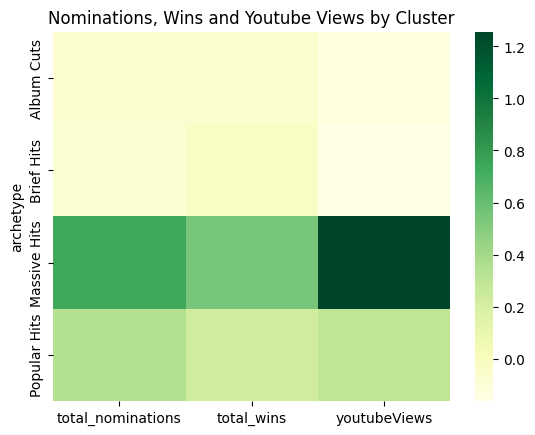

```python
sns.heatmap(grammy_and_views.groupby('archetype')[['total_nominations', 'total_wins',
                                                 'youtubeViews']].mean(),
            cmap='YlGn') #group by cluster
plt.title('Nominations, Wins and Youtube Views by Cluster')
```

### Youtube Views and Song Features

We can do an inner join on the song features DataFrame and the Youtube views DataFrame to compare all of our features for each song. While the datasets don't match up perfectly, it will be interesting to see what patterns emerge.

```python
charts_and_views = pd.merge(song_features_df, youtube_df, on='Song_clean') #inner join
charts_and_views = charts_and_views[['cluster', 'youtubeViews', 'archetype']] #drop non-numeric rows
charts_and_views.head()
```

|  | cluster | youtubeViews | archetype |
| --- | --- | --- | --- |
| 0 | 0 | 23370503.0 | Album Cuts |
| 1 | 0 | 17061197.0 | Album Cuts |
| 2 | 0 | 3808102.0 | Album Cuts |
| 3 | 0 | 3039532.0 | Album Cuts |
| 4 | 0 | 421541.0 | Album Cuts |

If we plot a histogram of Youtube views and cluster data, we see that the data is extremely right skewed.

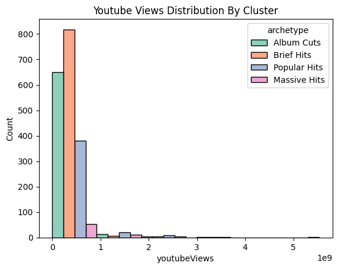

```python
#plot a histogram
sns.histplot(
    data=charts_and_views,
    x='youtubeViews',
    hue='archetype',
    multiple='dodge',
    bins=6,
    palette='Set2'
)

plt.title('Youtube Views Distribution By Cluster')
plt.show()
```

We can transformation of the data to better see the distribution. In the below histogram, we can see that as the archetype improves, the distribution of the data shifts.

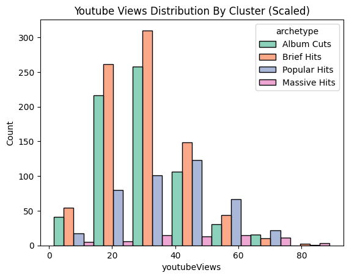

```python
#plot a histogram
sns.histplot(
    data=charts_and_views,
    x=charts_and_views['youtubeViews'] **0.2, #multiply views to fix skew
    hue='archetype',
    multiple='dodge',
    bins=7,
    palette='Set2'
)
plt.title('Youtube Views Distribution By Cluster (Scaled)')
plt.show()
```

Looking at the data for each cluster, we can see that increasing the cluster means skewing leftwards. This further supports our observations from earlier; as a song's charting performance improves on Spotify, it's Youtube views tend to also increase. This is an important obersevation: it indicates some correlation between Youtube popularity and charting popularity of a song. It also indicates the similarity between cluster 0 and 1, which we've observed previously. This helps support our hypothesis that, broadly speaking, you can evaluate a song's general popualarity using these two metrics.

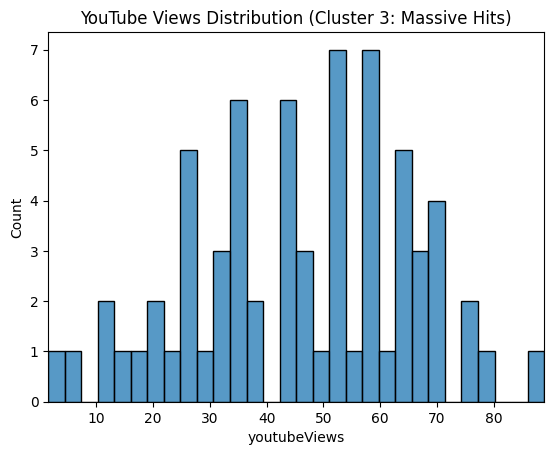

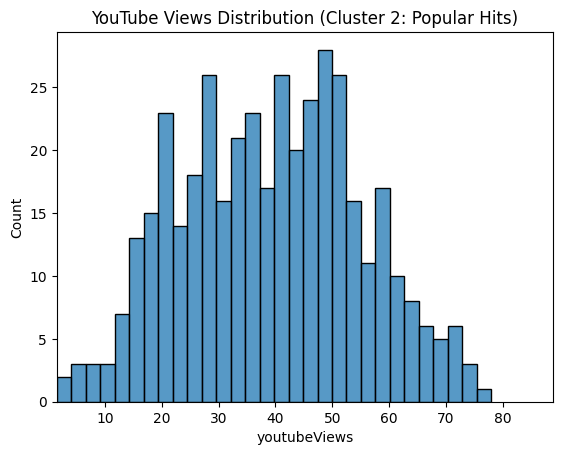

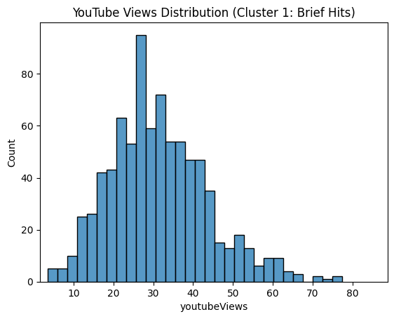

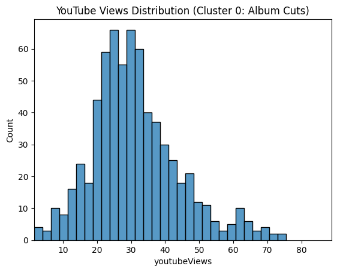

```python
#set max and min bounds
x_max = (charts_and_views['youtubeViews']**0.2).max()
x_min = (charts_and_views['youtubeViews']**0.2).min()

#plot each histogram seperately
sns.histplot(
    data=charts_and_views[charts_and_views['cluster'] == 3],
    x=charts_and_views[charts_and_views['cluster'] == 3]['youtubeViews'] **0.2, #scale views to fix skew (all scaled the same)
    bins=30,
)
plt.title('YouTube Views Distribution (Cluster 3: Massive Hits)')
plt.xlim(x_min, x_max) # set min and max for x axis
plt.show()



sns.histplot(
    data=charts_and_views[charts_and_views['cluster'] == 2],
    x=charts_and_views[charts_and_views['cluster'] == 2]['youtubeViews'] **0.2, #scale views to fix skew (all scaled the same)
    bins=30
)
plt.title('YouTube Views Distribution (Cluster 2: Popular Hits)')
plt.xlim(x_min, x_max) # set min and max for x axis
plt.show()



sns.histplot(
    data=charts_and_views[charts_and_views['cluster'] == 1],
    x=charts_and_views[charts_and_views['cluster'] == 1]['youtubeViews'] **0.2, #scale views to fix skew (all scaled the same)
    bins=30
)
plt.title('YouTube Views Distribution (Cluster 1: Brief Hits)')
plt.xlim(x_min, x_max) # set min and max for x axis
plt.show()


sns.histplot(
    data=charts_and_views[charts_and_views['cluster'] == 0],
    x=charts_and_views[charts_and_views['cluster'] == 0]['youtubeViews'] **0.2, #scale views to fix skew (all scaled the same)
    bins=30
)
plt.title('YouTube Views Distribution (Cluster 0: Album Cuts)')
plt.xlim(x_min, x_max) # set min and max for x axis
plt.show()
```

### Grammy and Youtube Views

```python
grammy_and_youtube = pd.merge(youtube_df, grammy_df, on='Song_clean', how='left') #left merge
grammy_and_youtube = grammy_and_youtube[['total_nominations','total_wins', 'youtubeViews']] #drop non numeric data
grammy_and_youtube = grammy_and_youtube.fillna({'total_nominations': 0, 'total_wins': 0,}) #fill nan with 0
grammy_and_youtube.head()
```

|  | total_nominations | total_wins | youtubeViews |
| --- | --- | --- | --- |
| 0 | 1.0 | 1.0 | 5.534218e+09 |
| 1 | 0.0 | 0.0 | 3.188181e+09 |
| 2 | 1.0 | 0.0 | 2.987593e+09 |
| 3 | 0.0 | 0.0 | 2.885044e+09 |
| 4 | 0.0 | 0.0 | 2.786524e+09 |

Since we want to soley look at if a song won or was nominated, and not the number of nominations or wins it recieved, we convert nominations into a categorical variable

```python
#turning total nominations into a yes or no classifier
grammy_and_youtube["if nominated"] = (
    grammy_and_youtube["total_nominations"]
    .apply(lambda x: "No" if x == 0 else "Yes")
    .astype("category")
)
```

```python
grammy_and_youtube.head()
```

|  | total_nominations | total_wins | youtubeViews | if nominated |
| --- | --- | --- | --- | --- |
| 0 | 1.0 | 1.0 | 5.534218e+09 | Yes |
| 1 | 0.0 | 0.0 | 3.188181e+09 | No |
| 2 | 1.0 | 0.0 | 2.987593e+09 | Yes |
| 3 | 0.0 | 0.0 | 2.885044e+09 | No |
| 4 | 0.0 | 0.0 | 2.786524e+09 | No |

We can now use a box plot to look at the density and distribution of the data for each category. We also decide to scale the views, as there is a large outlier that was skeweing our data. We can see from this chart that the majority of songs nominated for Grammys tend to have more views, while those not nomninated tend to have fewer. Additionally, we notice that the data with no views also has significantly more outliers.

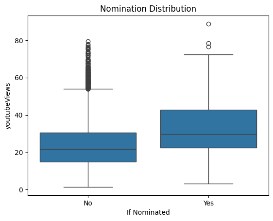

```python
#create a box plot to compare distribution in the not nominated and nominated categories
sns.boxplot(x="if nominated",
            y=grammy_and_youtube['youtubeViews']**0.2,
            data=grammy_and_youtube)

plt.xlabel("If Nominated")
plt.title("Nomination Distribution")
```

We can also look specfically at the distribution and density of the data using a violin plot. How pretty! We see that the majority of songs not nominated lie at a lower view count than those nominated.

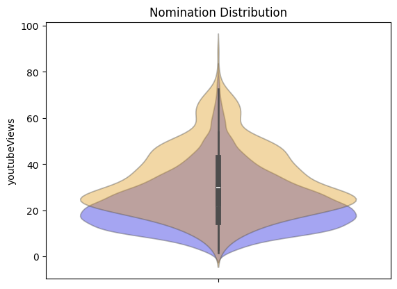

```python
#the not nominated violin plot.
sns.violinplot(
    data=grammy_and_youtube[grammy_and_youtube["if nominated"]=="No"],
    y=grammy_and_youtube[grammy_and_youtube["if nominated"]=="No"]['youtubeViews']**0.2, # scale variables to make it readable and understandable
    color="blue",
    alpha=0.4
)

#the nominated violin plot.
sns.violinplot(
    data=grammy_and_youtube[grammy_and_youtube["if nominated"]=="Yes"],
    y=grammy_and_youtube[grammy_and_youtube["if nominated"]=="Yes"]['youtubeViews']**0.2, # scale variables to make it readable and understandable
    color="orange",
    alpha=0.4
)

plt.title("Nomination Distribution")
plt.show()
```

## Future Analysis

From this analysis, we can see the rough correlation of a song's views on Youtube, chart performance on Spotify, and success at the Grammys. However, it is hard to tangibly join all of this analysis. In the future, we wish to build 2 regression models, training on each our digital metric datasets and predicting Grammy success. The goal of this dual-model strategy will be to determine which online popularity metric is the most "official" indication of a hit song.

### Model 1: Longevity & Rank To Predict Nominations

Our first model will be a classification model that takes the average longevity and rank of a song and predicts if it will be nominated or not. Our dependent variable (y) is Grammy nominations, and our independent variables (x) will be longevity and rank.

```python
grammy_and_chart.groupby('if nominated', observed=False)[['longevity', 'mean_rank']].mean()
```

[output not shown]

Additionally, we can use this heat map to compare nomninations to the archetypes built by our cluster model above. We see that as the archetype improves, the frequency of getting nominated increases. This indicates a correlation between nominations and longevity and rank.

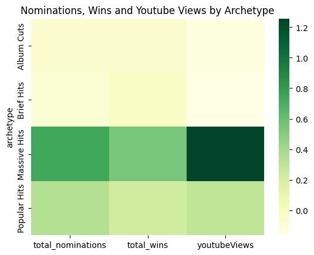

```python
sns.heatmap(grammy_and_views.groupby('archetype')[['total_nominations', 'total_wins',
                                                 'youtubeViews']].mean(),
            cmap='YlGn') #group by cluster
plt.title('Nominations, Wins and Youtube Views by Archetype')
```

### Model 2: Youtube Views To Predict Nominations

Our second model will be a classification model that uses a song's music video views to predict its Grammy nomination status. Our dependent variable (y) is Grammy nominations, and our independent variables (x) will be Youtube video views.

To support this model, we can again use indications of the correlation between Youtube streams and nominations. The box plot below shows that as views trend upward, nomination frequency also increases.

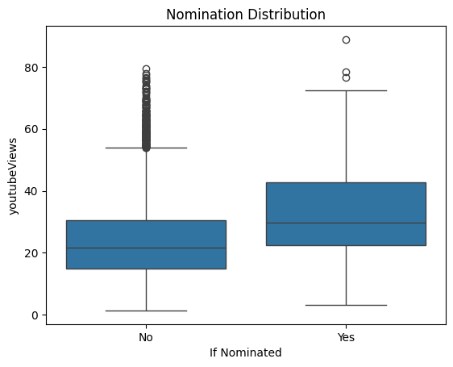

```python
#create a box plot to compare distribution in the not nominated and nominated categories
sns.boxplot(x="if nominated",
            y=grammy_and_youtube['youtubeViews']**0.2,
            data=grammy_and_youtube)

plt.xlabel("If Nominated")
plt.title("Nomination Distribution")
```

Lastly, we can use another pretty violin plot to see that the majority of the data in the not-nominated category tends to fall lower than the data in the nominated set. Besides a few outliers, this clearly indicates some correlation between Youtube views and nominations.

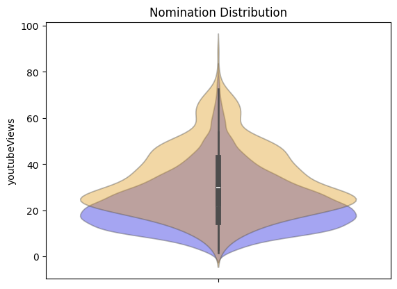

```python
#the not nominated violin plot.
sns.violinplot(
    data=grammy_and_youtube[grammy_and_youtube["if nominated"]=="No"],
    y=grammy_and_youtube[grammy_and_youtube["if nominated"]=="No"]['youtubeViews']**0.2, # scale variables to make it readable and understandable
    color="blue",
    alpha=0.4
)

#the nominated violin plot.
sns.violinplot(
    data=grammy_and_youtube[grammy_and_youtube["if nominated"]=="Yes"],
    y=grammy_and_youtube[grammy_and_youtube["if nominated"]=="Yes"]['youtubeViews']**0.2, # scale variables to make it readable and understandable
    color="orange",
    alpha=0.4
)

plt.title("Nomination Distribution")
plt.show()
```

```python
!pip install nbconvert
!pip install --upgrade jinja2

!jupyter nbconvert --to html "/content/drive/MyDrive/Colab Notebooks/Milestone 2"
```